# Etude de santé publique avec R

[figure not shown]

# I) Préparation de l’environnement R et importation des données

## 1) Initialisation des packages

```r
library(ggplot2)
library(ggrepel)
library(gridExtra)
library(dplyr)
library(tidyr)
library(maps)

options(scipen=999)
```

## 2) Importation des données

```r
aide_alimentaire_en <- read.csv("B:/OpenClassRooms/Projet4/Data/DATA_en/aide_alimentaire_en.csv", encoding="UTF-8", sep=";")
dispo_alimentaire_animal_en <- read.csv("B:/OpenClassRooms/Projet4/Data/DATA_en/dispo_alimentaire_animal_en.csv", encoding="UTF-8", sep=";")
dispo_alimentaire_vegetal_en <- read.csv("B:/OpenClassRooms/Projet4/Data/DATA_en/dispo_alimentaire_vegetal_en.csv", encoding="UTF-8", sep=";")
bilan_cereale <- read.csv("B:/OpenClassRooms/Projet4/Data/DATA_en/bilan_cereale.csv", encoding="UTF-8", sep=";")
pib_en <- read.csv("B:/OpenClassRooms/Projet4/Data/DATA_en/pib_en.csv", encoding="UTF-8", sep=";")
population_en <- read.csv("B:/OpenClassRooms/Projet4/Data/DATA_en/population_en.csv", encoding="UTF-8", sep=";")
sous_nutrition_en <- read.csv("B:/OpenClassRooms/Projet4/Data/DATA_en/sous_nutrition_en.csv", encoding="UTF-8", sep=";")

dispo_alimentaire_total_en <- rbind(dispo_alimentaire_vegetal_en,dispo_alimentaire_animal_en)
```

## 3) Préparation de la carte du monde pour représentations

Le nom des Pays est différents selon. Afin de réaliser une carte avec les données de la FAO, il faut que le nom des pays fourni par les donénes correspondent au au nom des pays des Package de cartographie. j’ai noté un certains nombre de noms différents :

```r
world_map <- map_data("world")

world_mapv2=world_map
world_mapv2=world_mapv2 %>% mutate(region = replace(region, region == "China" & subregion == "Macao" , "China, Macao SAR"))
world_mapv2=world_mapv2 %>% mutate(region = replace(region, region == "China" & subregion == "Hong Kong" , "China, Hong Kong SAR"))
world_mapv2=world_mapv2 %>% mutate(region = replace(region, region == "Swaziland" , "Eswatini"))
world_mapv2=world_mapv2 %>% mutate(region = replace(region, region == "Ivory Coast" , "Cote d'Ivoire"))
world_mapv2=world_mapv2 %>% mutate(region = replace(region, region == "Tanzania" , "United Republic of Tanzania"))
world_mapv2=world_mapv2 %>% mutate(region = replace(region, region == "Republic of Congo" , "Congo"))
world_mapv2=world_mapv2 %>% mutate(region = replace(region, region == "Vietnam" , "Viet Nam"))
world_mapv2=world_mapv2 %>% mutate(region = replace(region, region == "Iran" , "Iran (Islamic Republic of)"))
world_mapv2=world_mapv2 %>% mutate(region = replace(region, region == "North Korea" , "Democratic People's Republic of Korea"))
world_mapv2=world_mapv2 %>% mutate(region = replace(region, region == "Laos" , "Lao People's Democratic Republic"))
world_mapv2=world_mapv2 %>% mutate(region = replace(region, region == "Grenadines" , "Saint Vincent and the Grenadines"))
world_mapv2=world_mapv2 %>% mutate(region = replace(region, region == "Saint Vincent" , "Saint Vincent and the Grenadines"))
world_mapv2=world_mapv2 %>% mutate(region = replace(region, region == "Trinidad" , "Trinidad and Tobago"))
world_mapv2=world_mapv2 %>% mutate(region = replace(region, region == "Tobago" , "Trinidad and Tobago"))
world_mapv2=world_mapv2 %>% mutate(region = replace(region, region == "Venezuela" , "Venezuela (Bolivarian Republic of)"))
world_mapv2=world_mapv2 %>% mutate(region = replace(region, region == "Syria" , "Syrian Arab Republic"))
world_mapv2=world_mapv2 %>% mutate(region = replace(region, region == "Russia" , "Russian Federation"))
world_mapv2=world_mapv2 %>% mutate(region = replace(region, region == "Moldova" , "Republic of Moldova"))
world_mapv2=world_mapv2 %>% mutate(region = replace(region, region == "South Korea" , "Republic of Korea"))
world_mapv2=world_mapv2 %>% mutate(region = replace(region, region == "Czech Republic" , "Czechia"))
world_mapv2=world_mapv2 %>% mutate(region = replace(region, region == "China" , "China, mainland"))
world_mapv2=world_mapv2 %>% mutate(region = replace(region, region == "Cape Verde" , "Cabo Verde"))
world_mapv2=world_mapv2 %>% mutate(region = replace(region, region == "Bolivia" , "Bolivia (Plurinational State of)"))
world_mapv2=world_mapv2 %>% mutate(region = replace(region, region == "Antigua" , "Antigua and Barbuda"))
world_mapv2=world_mapv2 %>% mutate(region = replace(region, region == "Barbuda" , "Antigua and Barbuda"))
world_mapv2=world_mapv2 %>% mutate(region = replace(region, region == "Saint Kitts" , "Saint Kitts and Nevis"))
world_mapv2=world_mapv2 %>% mutate(region = replace(region, region == "Nevis" , "Saint Kitts and Nevis"))
world_mapv2=world_mapv2 %>% mutate(region = replace(region, region == "UK" , "United Kingdom of Great Britain and Northern Ireland"))
world_mapv2=world_mapv2 %>% mutate(region = replace(region, region == "USA" , "United States of America"))
world_mapv2=world_mapv2 %>% mutate(region = replace(region, region == "Taiwan" , "China, Taiwan Province of"))
```

# II) Analyse de la sous-nutrition mondiale

## 1) Proportion de personnes en état de sous-nutrition en 2017

```r
sum_ssnutri=sum(as.numeric(subset(sous_nutrition_en, ItemCode == "210011" & !is.na(as.numeric(Value)) & Value != "<0.1")$Value)*1000)
sum_pop=sum(population_en$Value)
paste(round((sum_ssnutri/sum_pop)*100, digits =2),"%")
```

```
## [1] "7.42 %"
```

On estime la population mondiale en 2017 à **7481124000** individus. A partir des données récoltées par la FAO, le nombre de personne en état de sous-nutrition est de **554800000**. Le nombre total de personne en état de sous-nutrition dans le monde est de **7.42 %**. Ces chiffres ne prennent en compte que les données des pays où la proportion de sous-nutrition est supérieure à 2,5%. Les résultats sont donc légèrement sous-évaluée.

### Représentations graphiques

```r
ssnutri.mapv2 <- left_join(subset(sous_nutrition_en, ItemCode =="210041" & !is.na(as.numeric(Value)) & Value != "<2.5"), world_mapv2, by = c("Area" = "region"))
region.texte.data <- subset(ssnutri.mapv2, as.numeric(Value) > 40) %>%
  group_by(Area) %>%
  summarise(long = mean(long), lat = mean(lat))
```

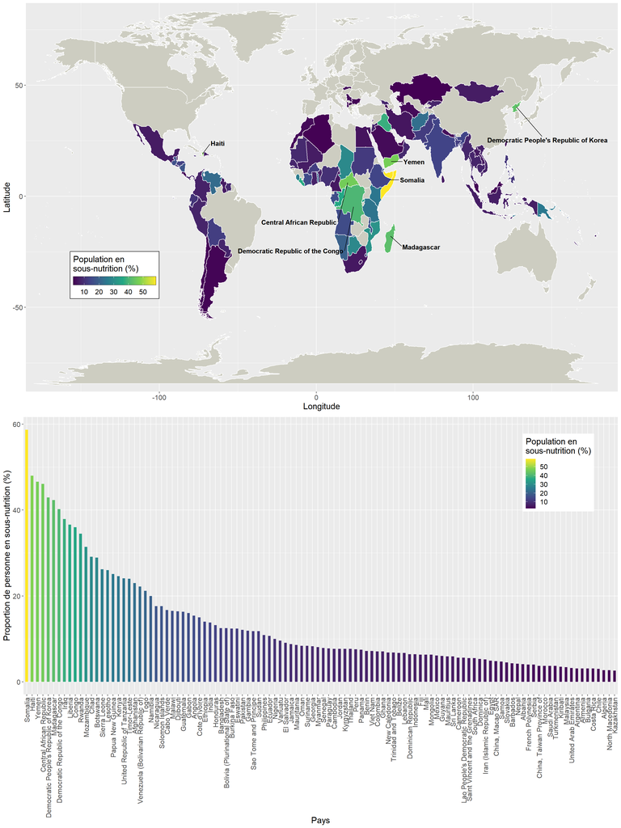

```r
PI_carte<-ggplot(ssnutri.mapv2, aes(long, lat))+
  geom_polygon(data = world_mapv2, aes(group = group), color = "white", fill = "ivory3" )+
  geom_polygon(aes(fill = as.numeric(Value),group = group), color = "white")+
  theme(legend.position = c(0.15, 0.3),
        legend.direction = "horizontal",
        legend.background = element_rect(colour = 'black', fill = 'white', linetype='solid'),
        text = element_text(size=15))+
  labs(y="Latitude", x="Longitude")+
  guides(fill = guide_colorbar(title = "Population en \nsous-nutrition (%)",
                               label.position = "bottom",
                               title.position = "top",
                               frame.colour = "black",
                               barwidth = 10,
                               barheight = 1)) +
  geom_text_repel(data = region.texte.data,
                  aes(label = Area),fontface = "bold",size = 4,
                  nudge_x = c(-31,20,-40, 10, 20,15, 15),
                  nudge_y = c(-18,-15,-20, 5,-5,0, 0))+
  scale_fill_viridis_c()+
  coord_cartesian(xlim = c(-168.0000, 175.000), ylim = c(-80.00000, 79.0000))

PI_bar<- ggplot(data=subset(sous_nutrition_en, ItemCode =="210041" & !is.na(as.numeric(Value)) & Value != "<2.5"), aes(x=reorder(Area,-as.numeric(Value)), y=as.numeric(Value),fill=as.numeric(Value))) +
  geom_bar(stat="identity", width=0.5)+
  theme(plot.title = element_text(hjust = 0.5, size = 16,face="bold"),
        axis.text.x = element_text(angle = 90, vjust = 0.5, hjust=1),
        legend.position = c(0.9, 0.8),
        text = element_text(size=15))+
    scale_fill_viridis_c()+
  labs(fill= "Population en \nsous-nutrition (%)",y="Proportion de personne en sous-nutrition (%)", x="Pays")

grid.arrange(PI_carte,PI_bar,ncol=1)
```

Cette carte indique le pourcentage de la population de chaque pays en sous-nutrition. Les noms des 7 pays affichés sur la carte sont les pays les plus à risque, où plus de 40% de leur population en état de sous-nutrition.

### Représentation du nombre de personne en sous-nutrition par pays

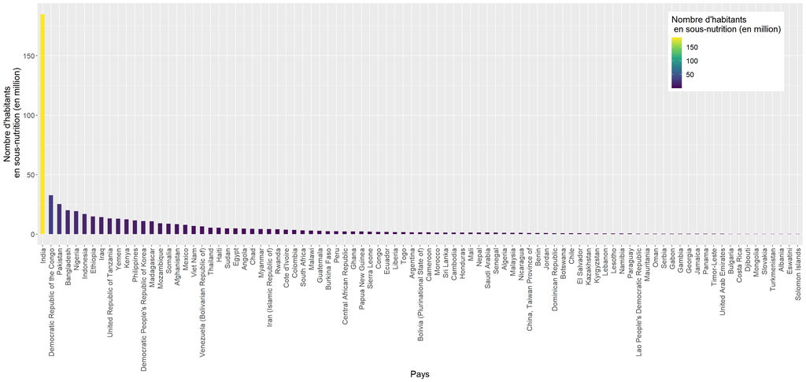

```r
PI_bar<- ggplot(data=subset(sous_nutrition_en, ItemCode =="210011" & !is.na(as.numeric(Value)) & Value != "<2.5"), aes(x=reorder(Area,-as.numeric(Value)), y=as.numeric(Value),fill=as.numeric(Value))) +
  geom_bar(stat="identity", width=0.5)+
  theme(plot.title = element_text(hjust = 0.5, size = 16,face="bold"),
        axis.text.x = element_text(angle = 90, vjust = 0.5, hjust=1),
        legend.position = c(0.9, 0.8),
        text = element_text(size=15))+
    scale_fill_viridis_c()+
  labs(fill= "Nombre d'habitants\n en sous-nutrition (en million)",y="Nombre d'habitants\n en sous-nutrition (en million)", x="Pays")
plot(PI_bar)
```

## 2) Répartition de l’aide alimentaire entre 2013 à 2016

```r
Aide_ali_sum=
  aide_alimentaire_en %>%
  group_by(Recipient.Country, Year) %>%
  summarise(Value = sum(Value))
```

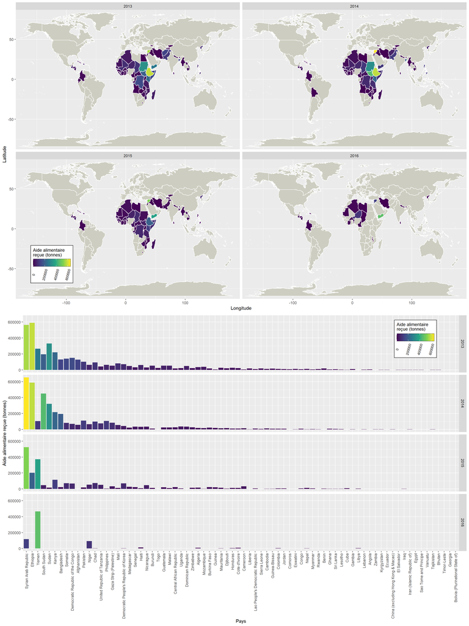

```r
Aide_ali_sum.mapv2 <- left_join(Aide_ali_sum, world_mapv2, by = c("Recipient.Country" = "region"))

PII_carte <- ggplot(Aide_ali_sum.mapv2, aes(long, lat))+
    geom_polygon(data=world_mapv2,aes(group=group), color = "white", fill = "ivory3" )+
    geom_polygon(aes(fill = as.numeric(Value), group=group), color = "white")+
    facet_wrap(Year~., ncol = 2)+
    theme(legend.position = c(0.08, 0.12),
          legend.direction = "horizontal",
          legend.background = element_rect(colour = 'black', fill = 'white', linetype='solid'),
          legend.text = element_text(angle = 75, vjust = 0.5, size = 8),
          legend.title=element_text(size=10))+
    labs(y="Latitude", x="Longitude")+
    guides(fill = guide_colorbar(title = "Aide alimentaire\nreçue (tonnes)",
                                 label.position = "bottom",
                                 title.position = "top",
                                 frame.colour = "black")) +
    scale_fill_viridis_c()+
    coord_cartesian(xlim = c(-168.0000, 175.000), ylim = c(-80.00000, 79.0000))

PII_bar <-ggplot(data= Aide_ali_sum, aes(x=reorder(Recipient.Country,-Value), y=Value, fill=as.numeric(Value))) +
    geom_bar(stat="identity")+
    theme(legend.position = c(0.9, 0.9),
          legend.background = element_rect(colour = 'black', fill = 'white', linetype='solid'),
          legend.text = element_text(angle = 75, vjust = 0.5, size = 8),
          legend.title = element_text(size=10,vjust = 1),
          axis.text.x = element_text(angle = 90, vjust = 0.5, hjust=1))+
    guides(fill = guide_colorbar(title = "Aide alimentaire\nreçue (tonnes)",
                                 direction = "horizontal",
                                 title.position = "top",
                                 frame.colour = "black"))+
    facet_grid(Year~.)+
    scale_fill_viridis_c()+
    labs(fill="Aide alimentaire\nreçue (tonnes)",y="Aide alimentaire reçue (tonnes)", x="Pays")

grid.arrange(PII_carte,PII_bar,ncol=1)
```

## 3) Résumé des 10 pays les plus en difficulté alimentaire

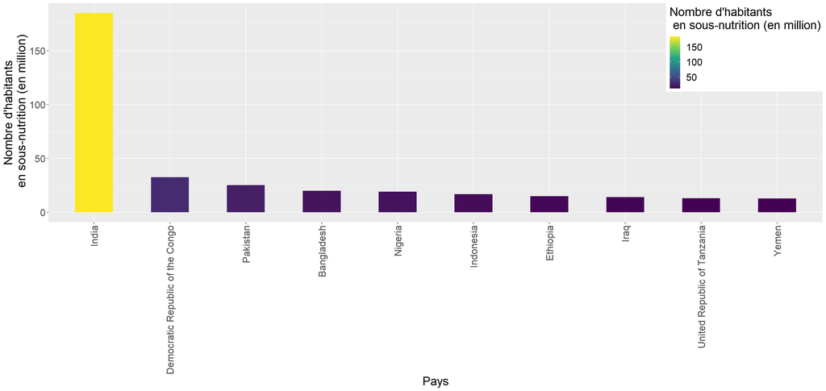

```r
ssNutri_Tot_10 =subset(sous_nutrition_en, ItemCode =="210011" & !is.na(as.numeric(Value)) & Value != "<2.5") %>% top_n(10, wt=as.numeric(Value))

PI_bar<- ggplot(data=ssNutri_Tot_10, aes(x=reorder(Area,-as.numeric(Value)), y=as.numeric(Value),fill=as.numeric(Value))) +
  geom_bar(stat="identity", width=0.5)+
  theme(plot.title = element_text(hjust = 0.5, size = 16,face="bold"),
        axis.text.x = element_text(angle = 90, vjust = 0.5, hjust=1),
        legend.position = c(0.9, 0.8),
        text = element_text(size=20))+
    scale_fill_viridis_c()+
  labs(fill= "Nombre d'habitants\n en sous-nutrition (en million)",y="Nombre d'habitants\n en sous-nutrition (en million)", x="Pays")
plot(PI_bar)
```

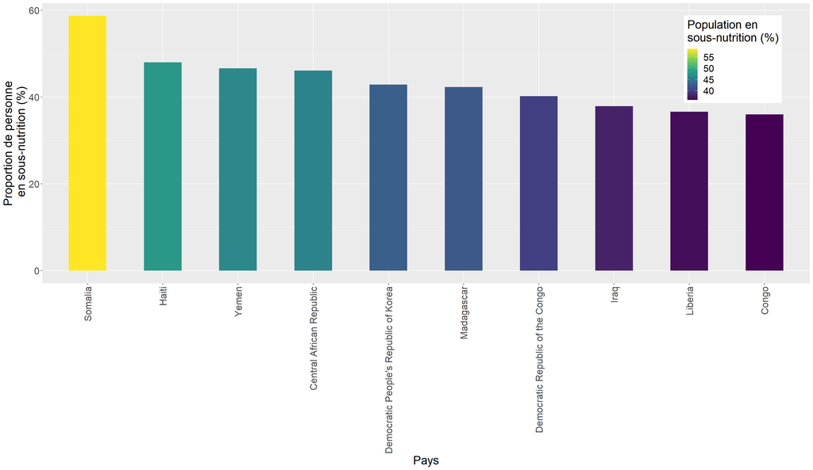

```r
ssNutri_Prev_10 =subset(sous_nutrition_en, ItemCode =="210041" & !is.na(as.numeric(Value)) & Value != "<0.1") %>% top_n(10, wt=as.numeric(Value))

PI_bar<- ggplot(data=ssNutri_Prev_10, aes(x=reorder(Area,-as.numeric(Value)), y=as.numeric(Value),fill=as.numeric(Value))) +
  geom_bar(stat="identity", width=0.5)+
  theme(plot.title = element_text(hjust = 0.5, size = 16,face="bold"),
        axis.text.x = element_text(angle = 90, vjust = 0.5, hjust=1),
        legend.position = c(0.9, 0.8),
        text = element_text(size=20))+
    scale_fill_viridis_c()+
  labs(fill= "Population en \nsous-nutrition (%)",y="Proportion de personne\n en sous-nutrition (%)", x="Pays")
plot(PI_bar)
```

### Au niveau de l’aide alimentaire :

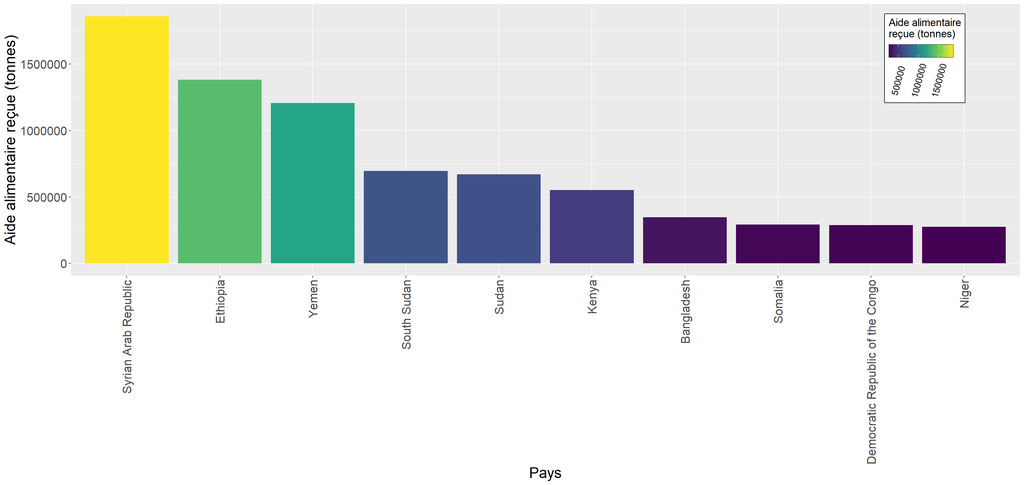

```r
Aide_ali_sumTot=
  aide_alimentaire_en %>%
  group_by(Recipient.Country) %>%
  summarise(Value = sum(Value))

Aide_ali_sum10= Aide_ali_sumTot %>% top_n(10, wt=as.numeric(Value))

PII_bar <-ggplot(data= Aide_ali_sum10, aes(x=reorder(Recipient.Country,-Value), y=Value, fill=as.numeric(Value))) +
    geom_bar(stat="identity")+
    theme(legend.position = c(0.9, 0.8),
          legend.background = element_rect(colour = 'black', fill = 'white', linetype='solid'),
          legend.text = element_text(angle = 75, vjust = 0.5, size = 12),
          legend.title = element_text(size=14,vjust = 1),
          axis.text.x = element_text(angle = 90, vjust = 0.5, hjust=1),
          text = element_text(size=20))+
    guides(fill = guide_colorbar(title = "Aide alimentaire\nreçue (tonnes)",
                                 direction = "horizontal",
                                 title.position = "top",
                                 frame.colour = "black"))+
    scale_fill_viridis_c()+
    labs(fill="Aide alimentaire\nreçue (tonnes)",y="Aide alimentaire reçue (tonnes)", x="Pays")
plot(PII_bar)
```

# III) Analyse de la disponibilité alimentaire par pays

## 1) le nombre théorique de personnes qui pourraient être nourries en 2017

Pour calculer le nombre théorique de personne qui pourraient être nourries en 2017, il faut tout d’abord additionner la disponibilité energétique en Kcal/personne/jour) de chaque catégorie d’aliments par pays.

```r
dispo_alimentaire_total_Kcal= subset(dispo_alimentaire_total_en, ElementCode == "664")


Dispo_alim_Kcal = dispo_alimentaire_total_Kcal %>%
                  group_by(Area)%>%
                  summarise(valeur = sum(Value))
```

Les besoins energétique pour un humain sont en moyenne de 2400 Kcal par jour. En divisant la disponibilité en Kcal par personne à 2400, on obtient la capacité de réponse aux besoins energétiques par personne d’un pays.

```r
Dispo_alim_Kcal$Dispo.personne=Dispo_alim_Kcal$valeur/2400
```

```r
Dispo_alim_Kcal=merge(Dispo_alim_Kcal,population_en[,c(2,9)])

Dispo_alim_Kcal$Kcal.popu = Dispo_alim_Kcal$Dispo.personne*(Dispo_alim_Kcal$Value*1000)

sum(Dispo_alim_Kcal$Kcal.popu)
```

```
## [1] 9144796081
```

Le nombre total de personne pouvant théoriquement être nourris sur Terre est de 9144796081.

### Répartition mondiale du taux d’approvisionnement

La taux d’approvisionnement d’un pays représente sa capacité à produire suffisament de nourriture pour combler les apports journaliers d’une personne. Par exemple, un taux de 0.8 signifie que le pays dispose d’une disponibilité alimentaire correspondant à 80% des besoins journaliers d’un individus.

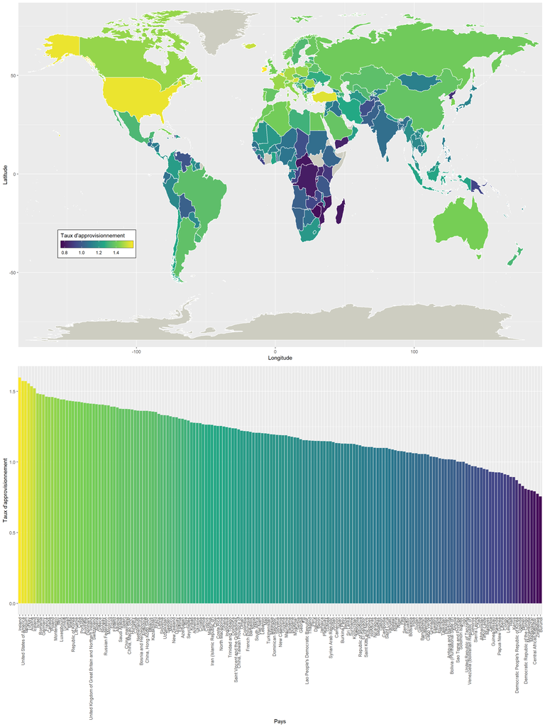

```r
DispoAlim.mapv2 <- left_join(Dispo_alim_Kcal,world_mapv2, by = c("Area" = "region"))


PIII_Dispo_carte <- ggplot(DispoAlim.mapv2, aes(long, lat))+
    geom_polygon(data=world_mapv2,aes(group=group), color = "white", fill = "ivory3" )+
    geom_polygon(aes(fill = as.numeric(Dispo.personne), group=group), color = "white")+
    theme(legend.position = c(0.15, 0.3),
        legend.direction = "horizontal",
        legend.background = element_rect(colour = 'black', fill = 'white', linetype='solid'))+
  labs(y="Latitude", x="Longitude")+
  guides(fill = guide_colorbar(title = "Taux d'approvisionnement",
                               label.position = "bottom",
                               title.position = "top",
                               frame.colour = "black",
                               barwidth = 10,
                               barheight = 1)) +
    scale_fill_viridis_c()+
    coord_cartesian(xlim = c(-168.0000, 175.000), ylim = c(-80.00000, 79.0000))


PIII_Dispo_bar <- ggplot(data= Dispo_alim_Kcal, aes(x=reorder(Area,-Dispo.personne), y=Dispo.personne)) +
  geom_bar(stat="identity", aes(fill=Dispo.personne), show.legend = FALSE)+
  theme(plot.title = element_text(hjust = 0.5, size = 16,face="bold"),
        axis.text.x = element_text(angle = 90, vjust = 0.5, hjust=1))+
  labs(y="Taux d'approvisionnement", x="Pays")+
  scale_fill_viridis_c()

grid.arrange(PIII_Dispo_carte,PIII_Dispo_bar,ncol=1)
```

Uniquement les extrêmes présentant une capacité d’approvisionnement <0.90 et supérieur à 1.45 :

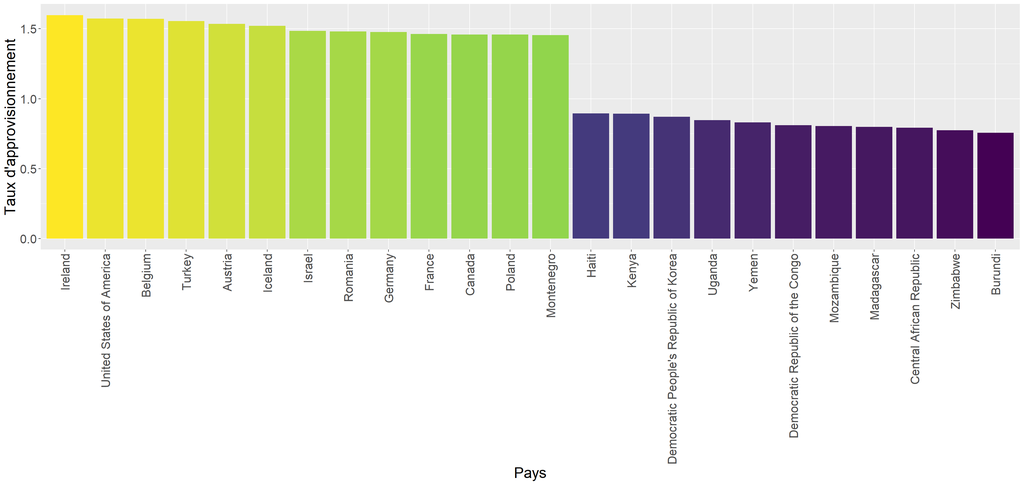

```r
ggplot(data= subset(Dispo_alim_Kcal, Dispo.personne <0.90 | Dispo.personne >1.45 ), aes(x=reorder(Area,-Dispo.personne), y=Dispo.personne)) +
  geom_bar(stat="identity", aes(fill=Dispo.personne), show.legend = FALSE)+
  theme(plot.title = element_text(hjust = 0.5, size = 16,face="bold"),
        axis.text.x = element_text(angle = 90, vjust = 0.5, hjust=1),
        text = element_text(size=20))+
  labs(y="Taux d'approvisionnement", x="Pays")+
  scale_fill_viridis_c()
```

## 2) le nombre théorique de personnes qui pourraient être nourries en 2017 avec des produits d’origine végétale

Le nombre de personne pouvant être nourris uniquement avec des **végétaux** est estimé de la même manière que précédemment, en ne selectionnant que les élément d’origine végétale

```r
dispo_alimentaire_vege_Kcal= subset(dispo_alimentaire_vegetal_en, ElementCode == "664")


Dispo_alim__vege_Kcal = dispo_alimentaire_vege_Kcal %>%
  group_by(Area)%>%
  summarise(valeur = sum(Value))

Dispo_alim__vege_Kcal$Dispo.personne=Dispo_alim__vege_Kcal$valeur/2400

Dispo_alim__vege_Kcal=merge(Dispo_alim__vege_Kcal,population_en[,c(2,9)])

Dispo_alim__vege_Kcal$Kcal.popu = Dispo_alim__vege_Kcal$Dispo.personne*(Dispo_alim__vege_Kcal$Value*1000)

sum(Dispo_alim__vege_Kcal$Kcal.popu)
```

```
## [1] 7517686381
```

Le nombre total de personne pouvant théoriquement être nourris sur Terre par de la nourriture d’origine **végétale** est de 7517686381.

# IV) Analyses de causes probables de la sous-nutrition mondiale

## 1) Utilisation de la disponibilité intérieure totale

### a) Utilisation par élément et par pays

Comment est utilisée la disponibilité intérieure par pays et globalement ?

Production + l’Import + l’export + Variation de stock = **disponibilité alimentaire** = Pertes + Semences + Traitement (raffinage) + Alimentation animale + Alimentation humaine.

La première étape est de récupérer uniquement les données d’utilisation alimentaire (Pertes + Semences + Traitement (raffinage) + Alimentation animale + Alimentation humaine)

```r
Utilisation_dispo <- subset(dispo_alimentaire_total_en, ElementCode %in% c("5142","5521","5123","5527","5131","5154"))
Utilisation_dispo <- Utilisation_dispo %>% mutate(Element = recode(Element,
                     "Losses" ="Pertes",
                     "Seed" = "Semences",
                     "Processing"="Traitement",
                     "Other uses (non-food)"="Autres.Utilisations",
                     "Feed"="Aliments.pour.animaux",
                     "Food"="Nourriture"))
```

La seconde étape est de récupérer la somme de chaque aliment par Pays et par Utilisation et de calculer leur proportion par rapport à l’utilisation totale (par pays).

```r
Utilisation_dispo_freq <-
  Utilisation_dispo %>%
  group_by(Area, Element) %>%
  summarise(valeur = sum(Value)) %>%
  mutate(freq = valeur / sum(valeur))
```

Le graphique ci-dessous illustre la proportion des différentes utilisations par pays.

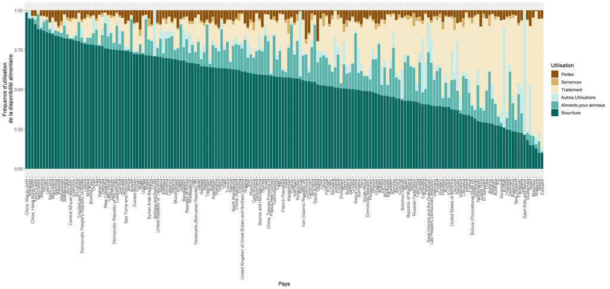

```r
Utilisation_dispo_freq$Area <- factor(Utilisation_dispo_freq$Area,
                                      levels=(Utilisation_dispo_freq %>% filter(Element=="Nourriture") %>%
                                      arrange(desc(freq)))$Area)

ggplot(data= Utilisation_dispo_freq, aes(x=Area, y=freq, fill= factor(Element, levels= c("Pertes","Semences","Traitement","Autres.Utilisations","Aliments.pour.animaux","Nourriture"))))+
  geom_bar(stat="identity")+
  scale_fill_brewer(palette="BrBG")+
  labs(fill = "Utilisation",y="Fréquence d'utilisation\n de la disponibilité alimentaire", x="Pays" )+
  theme(plot.title = element_text(hjust = 0.5, size = 16,face="bold"),
        axis.text.x = element_text(angle = 90, vjust = 0.5, hjust=1),
        text = element_text(size=12))
```

### 1b) Utilisation globale par élément

```r
Utilisation_dispo_freq_Tot=Utilisation_dispo %>%
  group_by(Element)%>%
  summarise(Value = sum(Value))%>%
  mutate(freq = Value / sum(Value))
```

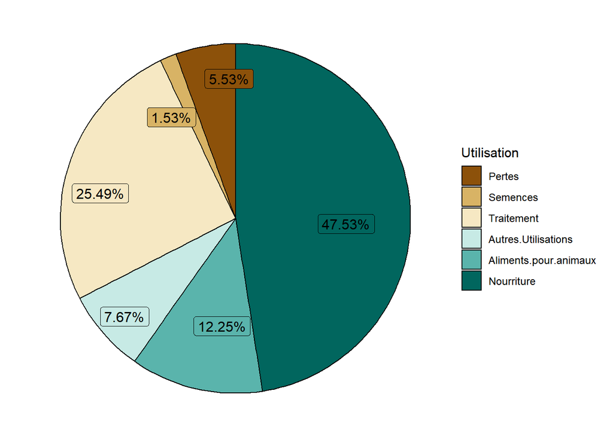

```r
ggplot(Utilisation_dispo_freq_Tot, aes(x="", y=freq, fill=factor(Element, levels=c("Pertes","Semences","Traitement","Autres.Utilisations","Aliments.pour.animaux","Nourriture")))) +
  geom_col(color=1) +
  scale_fill_brewer(palette="BrBG")+
  geom_label_repel(aes(x=1.2,label=paste0(round(freq*100,2),"%")),position = position_stack(vjust = 0.5), size=4, show.legend   =FALSE)+
  labs(fill = "Utilisation")+
  coord_polar("y", start=0)+
  theme_void()
```

### 2a) Utilisation des céréales par élément et par pays

```r
Utilisation_cereales <-  bilan_cereale %>%
  group_by(Area, Element) %>%
  summarise(Value) %>%
  mutate(freq = Value / sum(Value))
```

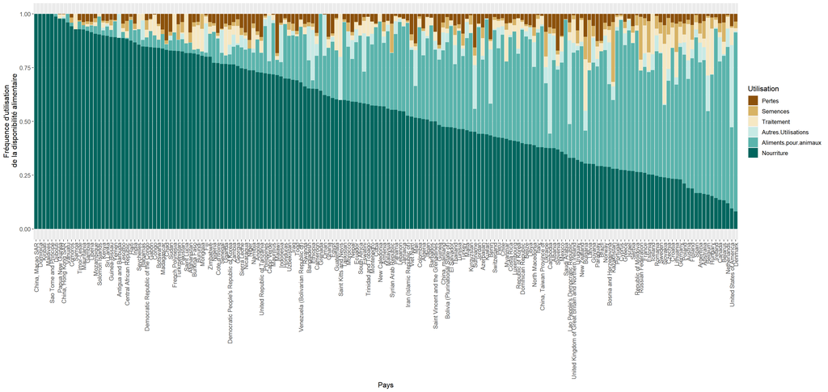

```r
Utilisation_cereales$Area <- factor(Utilisation_cereales$Area,
                                    levels=(Utilisation_cereales %>% filter(Element=="Nourriture") %>% arrange(desc(freq)))$Area)


ggplot(data= Utilisation_cereales, aes(x=Area, y=freq,
                                       fill= factor(Element, levels= c("Pertes","Semences","Traitement","Autres.Utilisations","Aliments.pour.animaux","Nourriture")))) +
  geom_bar(stat="identity")+
  scale_fill_brewer(palette="BrBG")+
  labs(fill = "Utilisation",y="Fréquence d'utilisation\n de la disponibilité alimentaire", x="Pays" )+
  theme(plot.title = element_text(hjust = 0.5, size = 16,face="bold"),
        axis.text.x = element_text(angle = 90, vjust = 0.5, hjust=1),
        text = element_text(size=12))
```

### 2b) Utilisation des céréales par élément

```r
Utilisation_cerealesTot=
  Utilisation_cereales[,-1] %>%
  group_by(Element)%>%
  summarise(Value = sum(Value))%>%
  mutate(freq = Value / sum(Value))
```

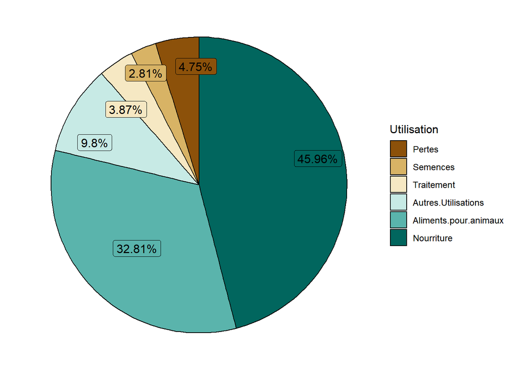

```r
ggplot(Utilisation_cerealesTot, aes(x="", y=freq, fill=factor(Element, levels= c("Pertes","Semences","Traitement","Autres.Utilisations","Aliments.pour.animaux","Nourriture")))) +
  geom_col(color=1) +
  scale_fill_brewer(palette="BrBG")+
  geom_label_repel(aes(x=1.2,label=paste0(round(freq*100,2),"%")),position = position_stack(vjust = 0.5), size=4, show.legend   =FALSE)+
  labs(fill = "Utilisation")+
  coord_polar("y", start=0)+
  theme_void()
```

### 3) Utilisation par PIB

Y a-t-il une différence d’utilisation des produits (céréaliers) en fonction du PIB du pays ?

La première étape est de joindre les données d’utilisation des céréales et le PIB (en US$ par habitant par an).

```r
Utilisation.cereal.PIB2 <- left_join(Utilisation_cereales, subset(pib_en, ElementCode =="6119" & !is.na(as.numeric(Value))), by = "Area")
```

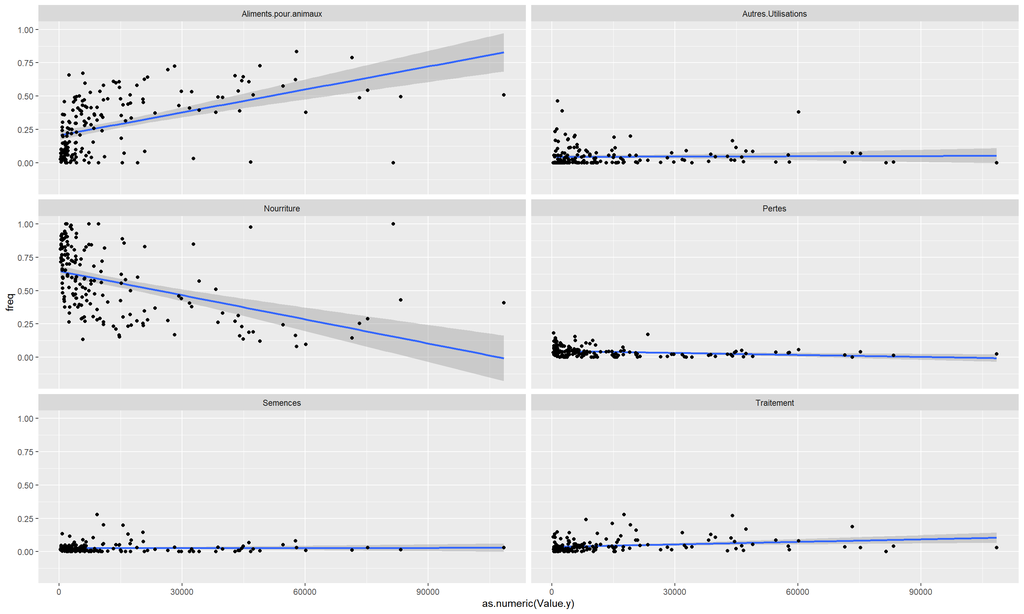

```r
ggplot(data = Utilisation.cereal.PIB2, aes(x=as.numeric(Value.y), y=freq, na.rm = TRUE))+
  geom_smooth(method='lm', formula= y~x)+
  geom_point(na.rm = TRUE)+
  facet_wrap(.~Element.x, ncol=2)
```

Test de la corrélation entre l’utilisation des céréales dans l’alimentation animale et le PIB par habitant :

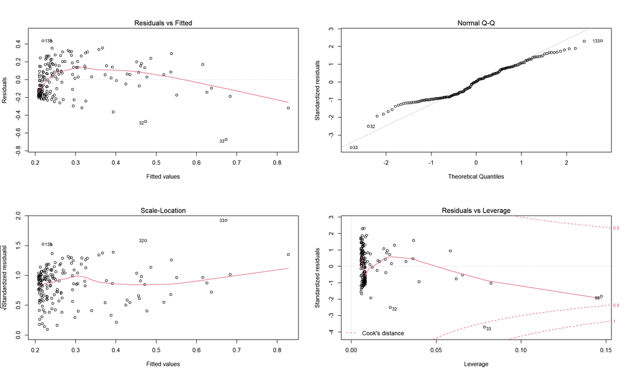

```r
par(mfrow=c(2,2))
plot(lm(data=subset(Utilisation.cereal.PIB2, Element.x =="Aliments.pour.animaux"), freq~Value.y))
```

```r
par(mfrow=c(1,1))

options( scipen = 0 )
model.Utilisation=lm(data=subset(Utilisation.cereal.PIB2, Element.x =="Aliments.pour.animaux"), freq~Value.y)
summary(model.Utilisation)
```

```
##
## Call:
## lm(formula = freq ~ Value.y, data = subset(Utilisation.cereal.PIB2,
##     Element.x == "Aliments.pour.animaux"))
##
## Residuals:
##     Min      1Q  Median      3Q     Max
## -0.6735 -0.1616  0.0050  0.1488  0.4381
##
## Coefficients:
##              Estimate Std. Error t value Pr(>|t|)
## (Intercept) 2.058e-01  1.745e-02  11.790  < 2e-16 ***
## Value.y     5.738e-06  7.508e-07   7.642 1.35e-12 ***
## ---
## Signif. codes:  0 '***' 0.001 '**' 0.01 '*' 0.05 '.' 0.1 ' ' 1
##
## Residual standard error: 0.1895 on 175 degrees of freedom
##   (1 observation effacée parce que manquante)
## Multiple R-squared:  0.2502, Adjusted R-squared:  0.2459
## F-statistic:  58.4 on 1 and 175 DF,  p-value: 1.35e-12
```

```r
options( scipen = 999 )
```

Il semblerait que plus le PIB par habitant est élevé, plus la part de la disponibilité intérieure utilisée pour l’alimentation animale est importante (exception forte : Macao )

## 2) L’inégalité de l’accès à la nourriture

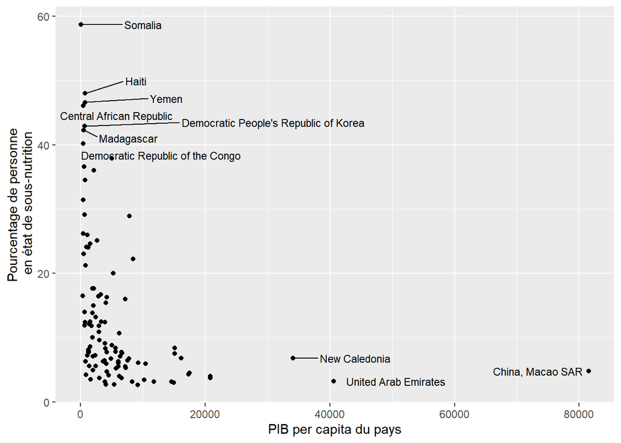

```r
#merge PIB et ss nutriprev

ssNutriPrev_PIBperC <- merge(subset(pib_en, ElementCode == '6119'),
                             subset(sous_nutrition_en, ItemCode =="210041" & !is.na(as.numeric(Value)) & Value != "<0.1"),
                             by = "Area")

ggplot(data = ssNutriPrev_PIBperC, aes(x=Value.x, y=as.numeric(Value.y), na.rm = TRUE))+
  geom_point(na.rm = TRUE)+
  geom_text_repel(data = subset(ssNutriPrev_PIBperC,as.numeric(Value.y) > 40 | Value.x >30000 ),
    size = 3,aes(label = Area),  max.overlaps = Inf,
    force_pull   = 0,
    nudge_x = 10000)+
 labs(x = "PIB per capita du pays", y="Pourcentage de personne\n en état de sous-nutrition")
```

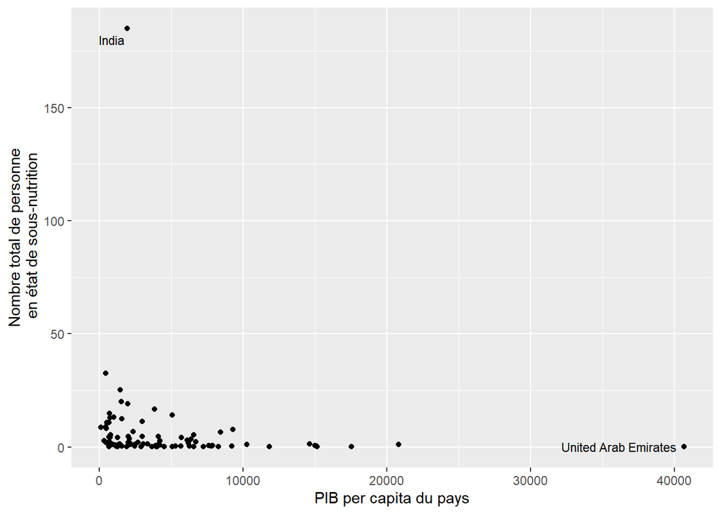

```r
#merge PIP et ssnutritot
ssNutriTot_PIBperC <- merge(subset(pib_en, ElementCode == '6119'),
subset(sous_nutrition_en, ItemCode =="210011" & !is.na(as.numeric(Value)) & Value != "<2.5"), by = "Area")

ggplot(data = ssNutriTot_PIBperC, aes(x=Value.x, y=as.numeric(Value.y), na.rm = TRUE))+
  geom_point(na.rm = TRUE)+
  geom_text_repel(data = subset(ssNutriTot_PIBperC,as.numeric(Value.y) > 50 | Value.x >30000 ),
    size = 3,aes(label = Area),  max.overlaps = Inf,
    force_pull   = 0)+
  labs(x = "PIB per capita du pays", y="Nombre total de personne\n en état de sous-nutrition")
```

Nouvelle Calédonie Emirats Arabes Unis Macao

Le cas de l’Inde :

Capacité d’approvisionnement de 1.06 (elle est capable de produire 106% des besoins journaliers de ses habitants) 13.8% de la population sous alimentée Soit 185 Millions de personne

## 3) La politique d’utilisation de la disponibilité : exemple de la Thaïlande et du manioc

### a) Rappel des chiffres de la population totale et sous-alimentée

```r
population_en[population_en$Area == "Thailand" & population_en$Item == "Population",]$Value*1000
```

```
## [1] 69210000
```

```r
as.numeric(sous_nutrition_en[sous_nutrition_en$Area == "Thailand" &
                  sous_nutrition_en$ItemCode == "210041",]$Value)
```

```
## [1] 7.7
```

```r
as.numeric(sous_nutrition_en[sous_nutrition_en$Area == "Thailand" &
                           sous_nutrition_en$ItemCode == "210011",]$Value)*1000000
```

```
## [1] 5400000
```

La population totale de la Thailand est de **69210000** dont **5400000** personnes sont en état de sous nutrition, soit **7.7 %** de la population.

### b) L’utilisation de la disponibilité du manioc

```r
dispo_alimentaire_total_en[dispo_alimentaire_total_en$Area == "Thailand" &
                          dispo_alimentaire_total_en$Item == "Cassava and products"&
                          dispo_alimentaire_total_en$Element == "Production",]$Value
```

```
## [1] 30495
```

```r
dispo_alimentaire_total_en[dispo_alimentaire_total_en$Area == "Thailand" &
                          dispo_alimentaire_total_en$Item == "Cassava and products" &
                          dispo_alimentaire_total_en$Element == "Export Quantity",]$Value
```

```
## [1] 29409
```

```r
(29409/30495)*100
```

```
## [1] 96.43876
```

La Thailand produit **30495 tonnes** de manioc et ses dérivés. Cependant, elle en exporte **29409 tonnes** soit **96.44 %** de sa production.

### c) Le manioc pour combattre la sous-nutrition

La valeur energétique du manioc est de **157 kcal** pour 100g (0,1 kg). Avec une production de 30495 tonnes, la Thailand serait en capacité de nourrir **19948812** personnes. Afin de subvenir au besoin de sa population en sous-nutrition, il faudrait **8254.78 tonnes** de manioc, soit **27.07 %** de leur production totale.

```r
(157*30495*1000 / (0.1))/2400
```

```
## [1] 19948813
```

```r
(5400000*30495)/19948813
```

```
## [1] 8254.777
```

```r
paste((8254.777/30495)*100,"%")
```

```
## [1] "27.0692802098705 %"
```